# Week 3

Transportation problem with dummy destination from text file

Gareth Green

# Example with a Dummy Destination, pg 327

The NORTHERN AIRPLANE COMPANY builds commercial airplanes

- The last stage of production is to produce the jet engines and then to install them in the completed airplane frame
- The company has been working under some contracts to deliver a considerable number of airplanes in the near future
- Production of the jet engines for these planes must now be scheduled for the next four months
- To meet the contracted dates for delivery, the company must supply engines for installation in the quantities indicated in the second column of the Table 9.7
- The cumulative number of engines produced by the end of months 1, 2, 3, and 4 must be at least 10, 25, 50, and 70
- Because of the variations in production costs, it may well be worthwhile to produce some of the engines a month or more before they are scheduled for installation
- **The drawback is that such engines must be stored until the scheduled installation (the airplane frames will not be ready early) at a storage cost of $15,000 per month**

# Cost and production data

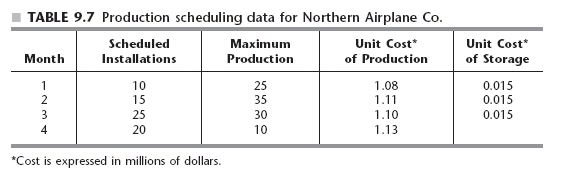

# Schedule possible production cost and supply

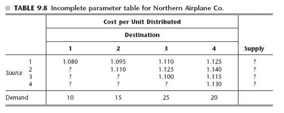

# Incorporate dummy destination for storage

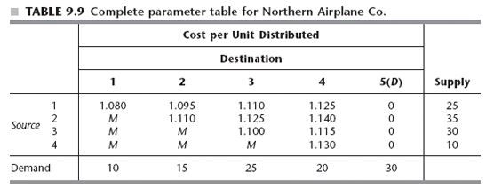

# Build and solve the model

This time load model from a text file

```r
# Load the model from a text file
trans_9_1_ex2 <- read.lp("W3-3-2_trans_9_1_ex2.lp", type = "lp")
```

```r
# Solve the model
solve(trans_9_1_ex2)
```

```
## [1] 0
```

|  | R1 | R2 | R3 | R4 | R5 | R6 | R7 | R8 | R9 | C1 | C2 | C3 | C4 | C5 | C6 | C7 | C8 | C9 | C10 | C11 | C12 | C13 | C14 | C15 | C16 | C17 | C18 | C19 | C20 |
| --- | --- | --- | --- | --- | --- | --- | --- | --- | --- | --- | --- | --- | --- | --- | --- | --- | --- | --- | --- | --- | --- | --- | --- | --- | --- | --- | --- | --- | --- |
| solution | 25 | 35 | 30 | 10 | 10 | 15 | 25 | 20 | 30 | 10 | 15 | 0 | 0 | 0 | 0 | 0 | 5 | 0 | 30 | 0 | 0 | 20 | 10 | 0 | 0 | 0 | 0 | 10 | 0 |
| duals/coef | -0.01 | 0 | -0.02 | -0.01 | 1.09 | 1.11 | 1.12 | 1.14 | 0 | 1.08 | 1.09 | 1.11 | 1.12 | 0 | 1000 | 1.11 | 1.12 | 1.14 | 0 | 1000 | 1000 | 1.1 | 1.12 | 0 | 1000 | 1000 | 1000 | 1.13 | 0 |
| Sens From | 25 | 35 | 30 | 10 | 10 | 15 | 25 | 20 | -inf | -inf | -inf | 1.11 | 1.12 | -0.01 | 1.1 | 1.11 | 1.12 | -inf | -0.35 | 1.07 | 1.09 | 1.1 | 1.12 | -0.02 | 1.09 | 1.1 | 1.12 | -inf | -0.01 |
| Sens Till | 25 | 35 | 30 | 10 | 10 | 15 | 25 | 20 | inf | 999.99 | 1.1 | inf | inf | inf | inf | inf | 1.13 | 1.14 | 0.01 | inf | inf | 1.1 | 1.12 | inf | inf | inf | inf | 1.14 | inf |

Objective Value = 77.3